# Introduction

## sfl-challenge

Code for the SFL take home challenge and assignment

**Author**: D. Bart Masters (d.bart.masters@gmail.com)

**Time requested**: Saturday, June 8th, 2024 12:00 pm CST

**Time due**: Tuesday, June 11th, 2024 12:00 pm CST

**Audience**: Deloitte-SFL Scientific

This notebook provides a framework to develop a classifier as described in the ReadMe.md and assignment document.

### Contents

- Initial Imports and Paths
- Data Collection and Processing
- Exploratory Data Analysis (EDA)
- Feature engineering and classifier data preparation
- Classifier fitting and evaluation: Classifiers that predict a composer for the labeled data
- Inference on unlabeled data: use the classifier predictions previously to determine which files do NOT belong to the 4 composers in the labeled data

### Files

`composer_class_funcs.py`: supporting file with function definitions used in this notebook.

## Initial Imports and Paths

```python
from composer_class_funcs import *
# ml packages
from sklearn.model_selection import train_test_split
from sklearn.preprocessing import LabelEncoder
from sklearn.ensemble import RandomForestClassifier, GradientBoostingClassifier
from sklearn.linear_model import LogisticRegression
from sklearn.svm import LinearSVC
from sklearn.calibration import CalibratedClassifierCV
```

```python
# file paths
train_midi_path = "./Challenge_DataSet/PS1/"
test_midi_path = "./Challenge_DataSet/PS2/"
```

## Data Collection and Processing

```python
# labeled data: creation and pandas dataframe
features, labels = load_dataset(train_midi_path, labeled=True, segments=4)
df_labeled = create_dataframe(features, labels)
```

```python
# unlabeled data: creation and pandas dataframe
# by specifying "labeled=False" this call will only produce 1 record per file, with the first 30 seconds of the file.
unlabeled_features = load_dataset(test_midi_path, labeled=False)
df_unlabeled=create_dataframe(unlabeled_features)
```

```python
# define numeric columns for later analysis
numeric_columns = df_labeled.select_dtypes(include=['float64', 'int64']).columns
```

## EDA

```python
# Display basic information about the labeled data
print("\nBasic Information about the DataFrame:")
print(df_labeled.info())

# Generate summary statistics
print("\nSummary Statistics of the DataFrame:")
print(df_labeled.describe())

# Check for missing values
print("\nMissing Values in the DataFrame:")
print(df_labeled.isnull().sum())
```

```
Basic Information about the DataFrame:
<class 'pandas.core.frame.DataFrame'>
RangeIndex: 776 entries, 0 to 775
Columns: 135 entries, filename to composer
dtypes: float64(130), int64(2), object(3)
memory usage: 818.6+ KB
None

Summary Statistics of the DataFrame:
        type          tpb  average_velocity  variance_velocity  Note_0  \
count  776.0   776.000000        776.000000         776.000000   776.0
mean     1.0   349.567010         80.592067         175.042063     0.0
std      0.0   129.619505         15.324991         185.708051     0.0
min      1.0   120.000000         36.000000           0.000000     0.0
25%      1.0   384.000000         70.332868          27.579599     0.0
50%      1.0   384.000000         81.389757         138.263244     0.0
75%      1.0   384.000000         91.440289         238.879137     0.0
max      1.0  1024.000000        127.000000        1081.281516     0.0

       Note_1  Note_2  Note_3  Note_4  Note_5  ...  Note_118  Note_119  \
count   776.0   776.0   776.0   776.0   776.0  ...     776.0     776.0
mean      0.0     0.0     0.0     0.0     0.0  ...       0.0       0.0
std       0.0     0.0     0.0     0.0     0.0  ...       0.0       0.0
min       0.0     0.0     0.0     0.0     0.0  ...       0.0       0.0
25%       0.0     0.0     0.0     0.0     0.0  ...       0.0       0.0
50%       0.0     0.0     0.0     0.0     0.0  ...       0.0       0.0
75%       0.0     0.0     0.0     0.0     0.0  ...       0.0       0.0
max       0.0     0.0     0.0     0.0     0.0  ...       0.0       0.0

       Note_120  Note_121  Note_122  Note_123  Note_124  Note_125  Note_126  \
count     776.0     776.0     776.0     776.0     776.0     776.0     776.0
mean        0.0       0.0       0.0       0.0       0.0       0.0       0.0
std         0.0       0.0       0.0       0.0       0.0       0.0       0.0
min         0.0       0.0       0.0       0.0       0.0       0.0       0.0
25%         0.0       0.0       0.0       0.0       0.0       0.0       0.0
50%         0.0       0.0       0.0       0.0       0.0       0.0       0.0
75%         0.0       0.0       0.0       0.0       0.0       0.0       0.0
max         0.0       0.0       0.0       0.0       0.0       0.0       0.0

       Note_127
```

[output cut: 9 more lines]

```
[8 rows x 132 columns]

Missing Values in the DataFrame:
filename            0
type                0
tpb                 0
key                 0
average_velocity    0
                   ..
Note_124            0
Note_125            0
Note_126            0
Note_127            0
composer            0
Length: 135, dtype: int64
```

```python
# filenames
print('Labeled Files: ',df_labeled['filename'].unique().shape[0])
print('Unlabeled Files: ',df_unlabeled['filename'].unique().shape[0])
```

```
Labeled Files:  194
Unlabeled Files:  35
```

```python
# confirm they're all type 1:
## https://mido.readthedocs.io/en/latest/files/midi.html#file-types
## type 1 (synchronous): all tracks start at the same time
print(df_labeled.type.value_counts())
print(df_unlabeled.type.value_counts())
```

```
type
1    776
Name: count, dtype: int64
type
1    35
Name: count, dtype: int64
```

```python
# see some unique values of the key
df_labeled.key.value_counts()
```

```
key
C      112
Eb     100
        64
G       60
F       60
Ab      60
Bb      56
E       56
A       48
D       40
Cm      32
Fm      20
Dm      16
Bm      12
Am       8
Db       8
Gb       8
Gm       4
Em       4
Abm      4
F#       4
Name: count, dtype: int64
```

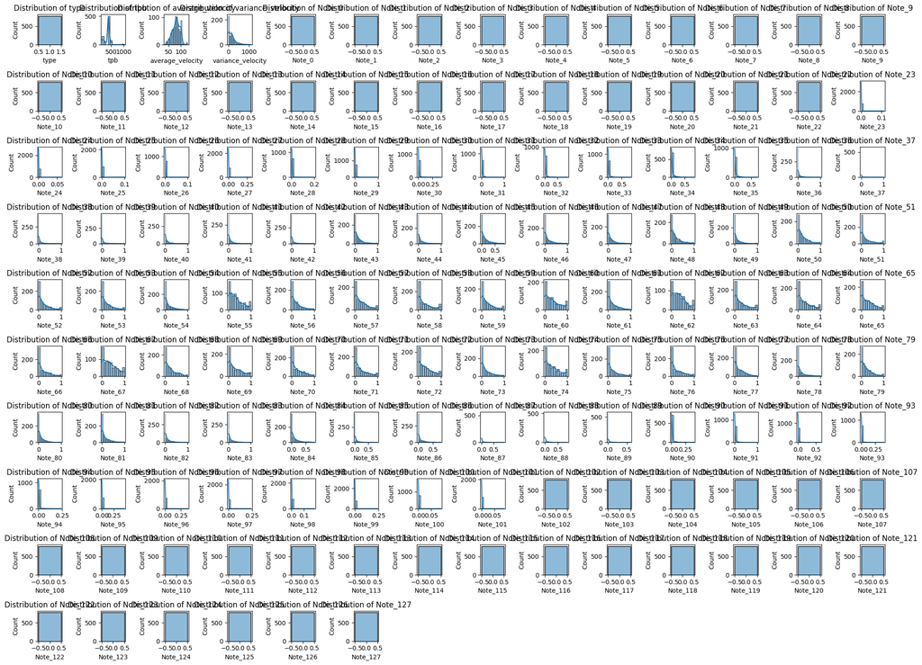

```python
# Visualize the distribution of each numeric feature
plt.figure(figsize=(20, 15))
for i, col in enumerate(numeric_columns):
    plt.subplot(10, 14, i+1)
    sns.histplot(df_labeled[col], kde=True)
    plt.title(f'Distribution of {col}')
plt.tight_layout()
plt.show()
```

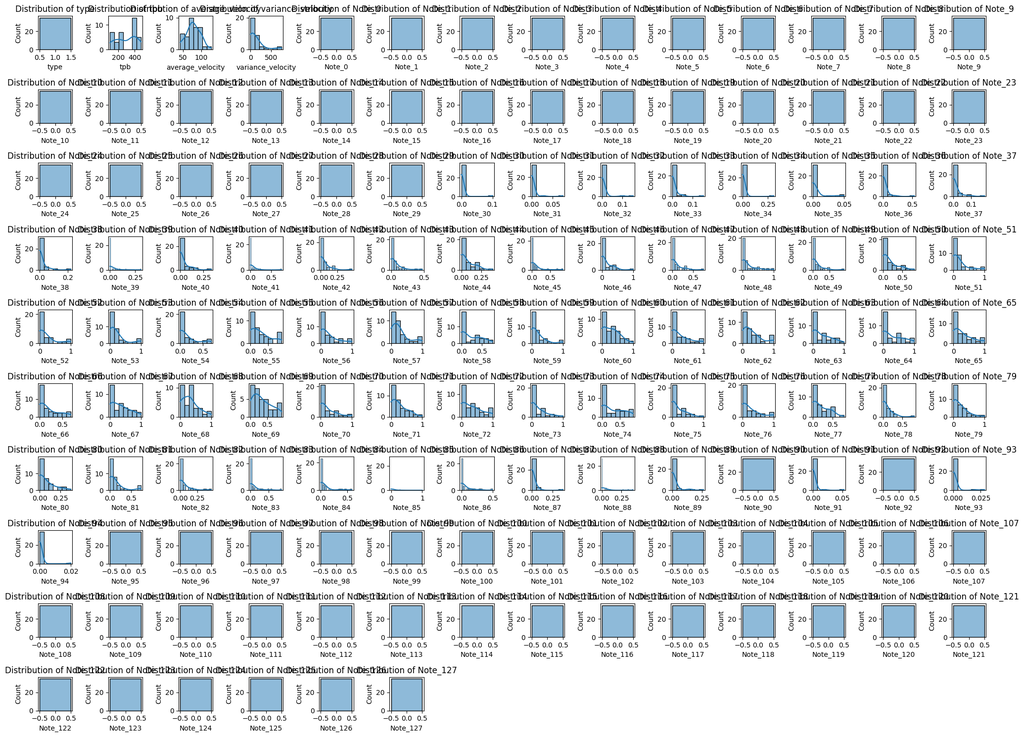

```python
# Visualize the distribution of each numeric feature for the unlabeled data to see if it's similar

plt.figure(figsize=(20, 15))
for i, col in enumerate(numeric_columns):
    plt.subplot(10, 14, i+1)
    sns.histplot(df_unlabeled[col], kde=True)
    plt.title(f'Distribution of {col}')
plt.tight_layout()
plt.show()
```

### Conclusion:

based on this, I'd remove notes 0-22, 105-127. The unlabeled dataset also has no info for these notes. See feature engineering and prep section for removal.

```python
## Commented out as this is not particularly useful
# Visualize correlations between numeric features

# plt.figure(figsize=(12, 10))
# correlation_matrix = df_labeled[numeric_columns].corr()
# sns.heatmap(correlation_matrix, annot=True, cmap='coolwarm', fmt='.2f')
# plt.title('Correlation Matrix')
# plt.show()
```

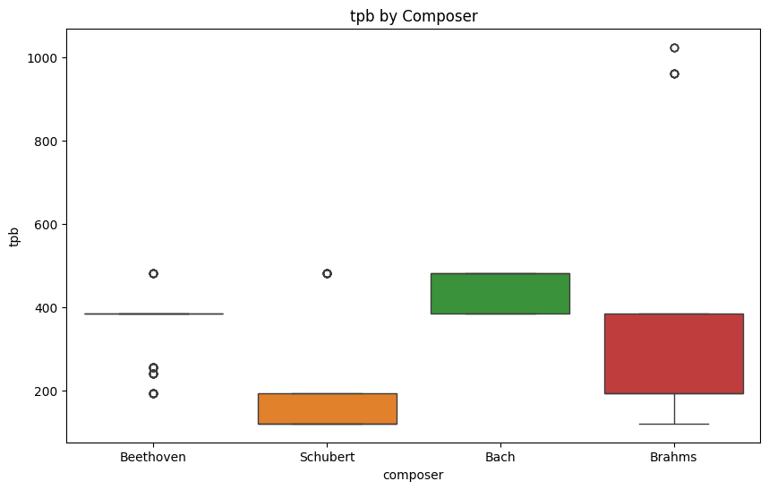

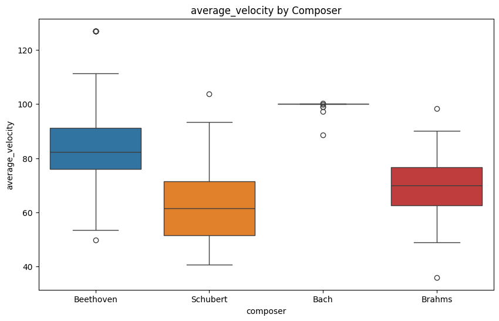

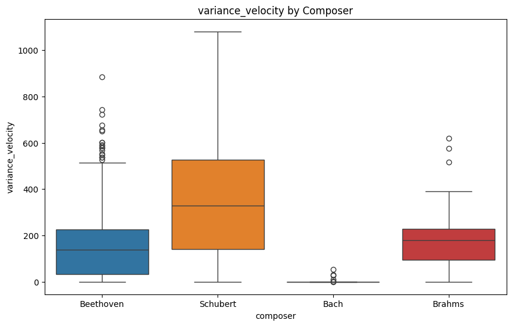

```python
# Visualize the relationship between the first 3 numeric features and the target (if applicable)
if 'composer' in df_labeled.columns:
    for i in range(1,4):
        plt.figure(figsize=(10, 6))
        sns.boxplot(x='composer', y=numeric_columns[i], data=df_labeled, hue='composer')
        plt.title(f'{numeric_columns[i]} by Composer')
        plt.show()
```

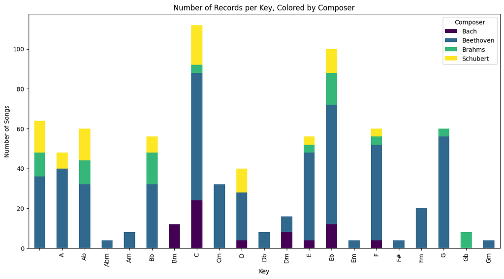

```python
# Prepare the data for the stacked bar chart
key_composer_counts = df_labeled.groupby(['key', 'composer']).size().unstack(fill_value=0)
# Plot the stacked bar chart
key_composer_counts.plot(kind='bar', stacked=True, figsize=(14, 7), colormap='viridis')
plt.title('Number of Records per Key, Colored by Composer')
plt.xlabel('Key')
plt.ylabel('Number of Songs')
plt.xticks(rotation=90)
plt.legend(title='Composer')
plt.show()
```

## Clean + Feature Engineer

```python
# Drop columns corresponding to notes 0-22 and 105-127 based on EDA
cols_to_drop = [f'Note_{i}' for i in list(range(0, 23)) + list(range(105, 128))]
df_labeled.drop(columns=cols_to_drop, inplace=True)
df_unlabeled.drop(columns=cols_to_drop, inplace=True)
```

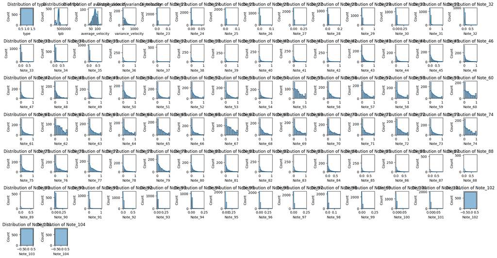

```python
# define numeric columns for later analysis
numeric_columns_cleaned = df_labeled.select_dtypes(include=['float64', 'int64']).columns

# Visualize the distribution of each numeric feature
plt.figure(figsize=(20, 15))
for i, col in enumerate(numeric_columns_cleaned):
    plt.subplot(10, 14, i+1)
    sns.histplot(df_labeled[col], kde=True)
    plt.title(f'Distribution of {col}')
plt.tight_layout()
plt.show()
```

```python
# replace Null keys with 'unk' value
df_labeled['key']=df_labeled['key'].fillna('unk')
df_unlabeled['key']=df_unlabeled['key'].fillna('unk')

# Encode the 'key' variable
label_encoder_key = LabelEncoder()
label_encoder_key.fit(df_labeled['key'].unique().tolist()+df_unlabeled['key'].unique().tolist())
df_labeled['key_encoded'] = label_encoder_key.transform(df_labeled['key'])
df_unlabeled['key_encoded'] = label_encoder_key.transform(df_unlabeled['key'])

# Encode the 'Composer' column: for labeled data only
label_encoder_composer = LabelEncoder()
df_labeled['composer'] = label_encoder_composer.fit_transform(df_labeled['composer'])
```

```python
# Define the features (X) and target (y)
X = df_labeled.drop(columns=['composer', 'filename','key'])
y = df_labeled['composer']

# Define features for unlabeled data
z = df_unlabeled.drop(columns=['filename','key'])
```

```python
# Split the data into training and testing sets
X_train, X_test, y_train, y_test = train_test_split(X, y, test_size=0.4, random_state=42)
```

```python
# view label distributions
print(label_encoder_composer.classes_,'\n')
print('train targets\n',y_train.value_counts())
print('\ntest targets\n',y_test.value_counts())
```

```
['Bach' 'Beethoven' 'Brahms' 'Schubert']

train targets
 composer
1    313
3     62
2     47
0     43
Name: count, dtype: int64

test targets
 composer
1    215
3     38
2     33
0     25
Name: count, dtype: int64
```

## Train Classifiers

### Logistic Regression

```python
# Train and evaluate the Logistic Regression model
log_reg = LogisticRegression(max_iter=10000, random_state=42)
log_reg.fit(X_train, y_train)
# predictions
y_pred_test_lr = log_reg.predict(X_test)
y_pred_train_lr = log_reg.predict(X_train)
# Get the classification probabilities for each class for test dataset
y_proba_test_lr = log_reg.predict_proba(X_test)
y_proba_train_lr = log_reg.predict_proba(X_train)
```

```
Logistic Regression :
AUC for Training Set: 0.9646
AUC for Test Set: 0.9278
Accuracy Score (Test): 0.8520900321543409

Classification Report (Test):
              precision    recall  f1-score   support

           0       0.92      0.88      0.90        25
           1       0.89      0.96      0.92       215
           2       0.53      0.30      0.38        33
           3       0.74      0.68      0.71        38

    accuracy                           0.85       311
   macro avg       0.77      0.71      0.73       311
weighted avg       0.83      0.85      0.84       311
```

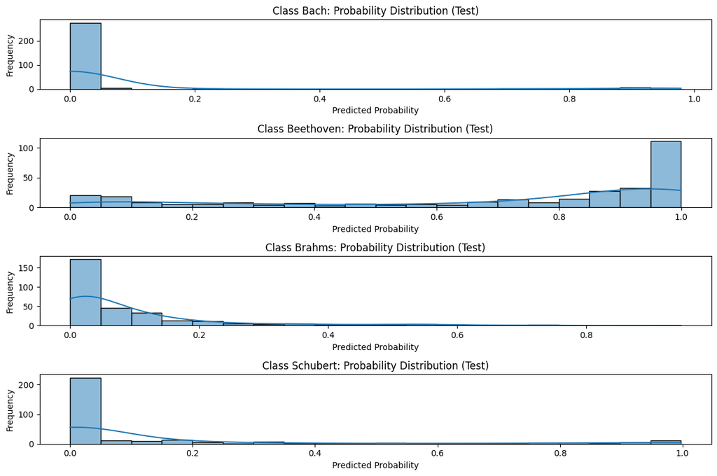

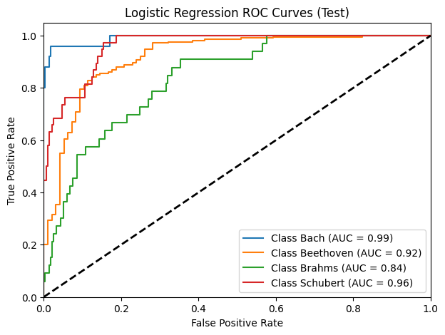

```python
model_eval("Logistic Regression", y_train, y_pred_train_lr, y_proba_train_lr, y_test, y_pred_test_lr, y_proba_test_lr, label_encoder_composer)
```

### SVM

```python
# Build and train the Random Forest classifier
svm_classifier = LinearSVC(penalty='l2', random_state=0, tol=1e-5)
# Wrap the LinearSVC classifier with CalibratedClassifierCV to obtain probabilities
calibrated_svc = CalibratedClassifierCV(estimator=svm_classifier, method='sigmoid')
calibrated_svc.fit(X_train, y_train)
# predictions
y_pred_test_svc = calibrated_svc.predict(X_test)
y_pred_train_svc = calibrated_svc.predict(X_train)
# Get the classification probabilities for each class for test dataset
y_proba_test_svc = calibrated_svc.predict_proba(X_test)
y_proba_train_svc = calibrated_svc.predict_proba(X_train)
```

```
Support Vector Machine (CV Calibrated) :
AUC for Training Set: 0.9613
AUC for Test Set: 0.8990
Accuracy Score (Test): 0.7652733118971061

Classification Report (Test):
              precision    recall  f1-score   support

           0       1.00      0.04      0.08        25
           1       0.76      1.00      0.86       215
           2       1.00      0.03      0.06        33
           3       0.85      0.58      0.69        38

    accuracy                           0.77       311
   macro avg       0.90      0.41      0.42       311
weighted avg       0.81      0.77      0.69       311
```

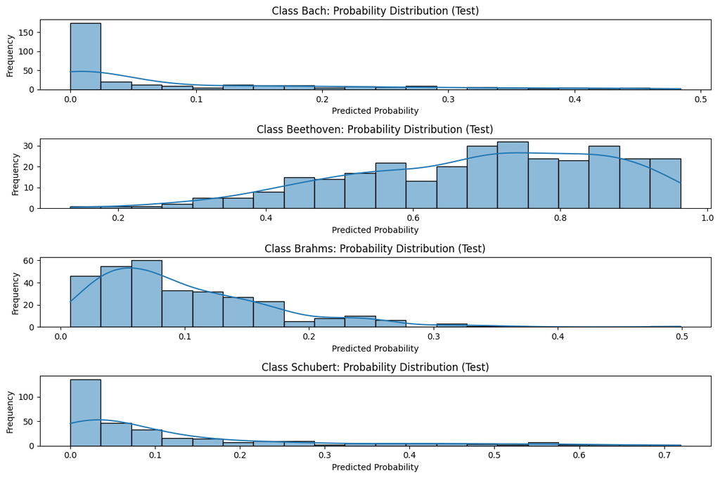

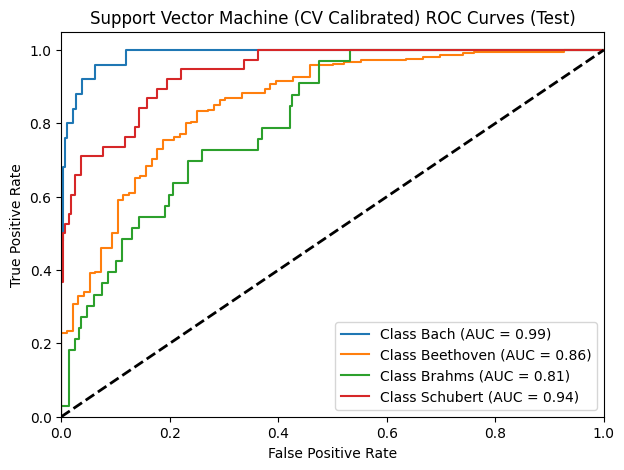

```python
model_eval("Support Vector Machine (CV Calibrated)", y_train, y_pred_train_svc, y_proba_train_svc, y_test, y_pred_test_svc, y_proba_test_svc, label_encoder_composer)
```

### Random Forest

```python
# Build and train the Random Forest classifier
rf_classifier = RandomForestClassifier(n_estimators=100, random_state=42)
rf_classifier.fit(X_train, y_train)
# predictions
y_pred_test_rf = rf_classifier.predict(X_test)
y_pred_train_rf = rf_classifier.predict(X_train)
# Get the classification probabilities for each class for test dataset
y_proba_test_rf = rf_classifier.predict_proba(X_test)
y_proba_train_rf = rf_classifier.predict_proba(X_train)
```

```
Random Forest :
AUC for Training Set: 1.0000
AUC for Test Set: 0.9817
Accuracy Score (Test): 0.9003215434083601

Classification Report (Test):
              precision    recall  f1-score   support

           0       1.00      0.80      0.89        25
           1       0.90      1.00      0.95       215
           2       0.92      0.33      0.49        33
           3       0.85      0.89      0.87        38

    accuracy                           0.90       311
   macro avg       0.92      0.76      0.80       311
weighted avg       0.90      0.90      0.88       311
```

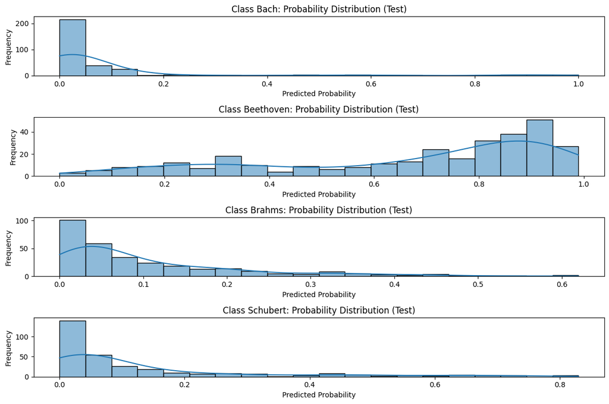

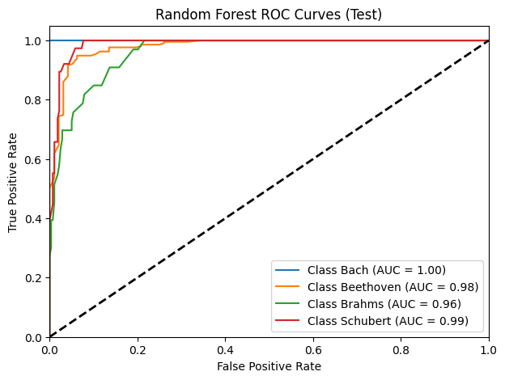

```python
model_eval("Random Forest", y_train, y_pred_train_rf, y_proba_train_rf, y_test, y_pred_test_rf, y_proba_test_rf, label_encoder_composer)
```

```
Top 10 feature importances:
tpb: 0.16502969025855685
average_velocity: 0.10770435750835838
variance_velocity: 0.058799156391242155
key_encoded: 0.03017052887092592
Note_72: 0.019637961965086256
Note_73: 0.018395205156501063
Note_69: 0.017180920689887087
Note_41: 0.015260346650089227
Note_50: 0.015058428956767093
Note_76: 0.01483325470612703
```

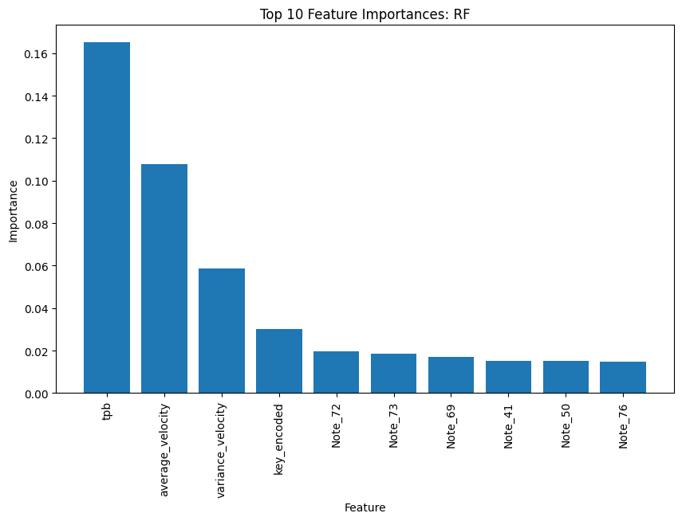

```python
rf_importances = top_feat(rf_classifier, "RF", X_train, n=10)
```

### GBM

```python
# Build and train the Random Forest classifier
gb_classifier = GradientBoostingClassifier(n_estimators=100, random_state=42)
gb_classifier.fit(X_train, y_train)

# predictions
y_pred_test_gb = gb_classifier.predict(X_test)
y_pred_train_gb = gb_classifier.predict(X_train)
# Get the classification probabilities for each class for test dataset
y_proba_test_gb = gb_classifier.predict_proba(X_test)
y_proba_train_gb = gb_classifier.predict_proba(X_train)
```

```
GBM :
AUC for Training Set: 1.0000
AUC for Test Set: 0.9509
Accuracy Score (Test): 0.8971061093247589

Classification Report (Test):
              precision    recall  f1-score   support

           0       0.74      0.92      0.82        25
           1       0.95      0.93      0.94       215
           2       0.71      0.67      0.69        33
           3       0.89      0.87      0.88        38

    accuracy                           0.90       311
   macro avg       0.82      0.85      0.83       311
weighted avg       0.90      0.90      0.90       311
```

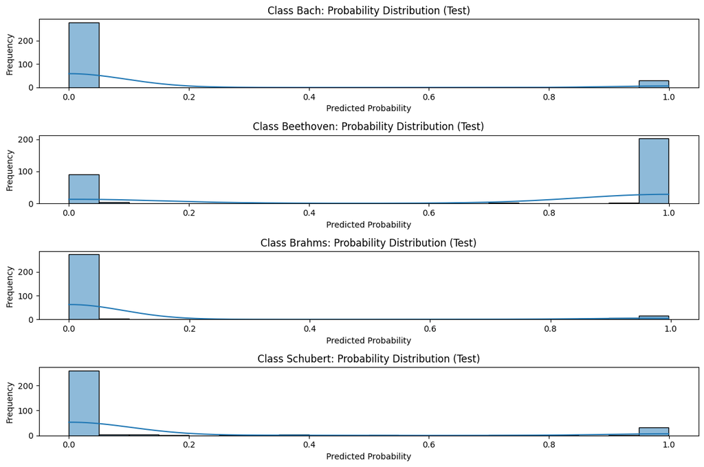

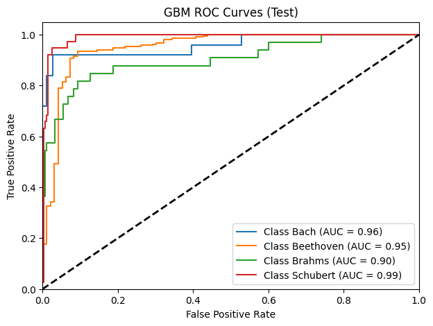

```python
model_eval("GBM", y_train, y_pred_train_gb, y_proba_train_gb, y_test, y_pred_test_gb, y_proba_test_gb, label_encoder_composer)
```

```
Top 10 feature importances:
tpb: 0.518686217060297
average_velocity: 0.25869092658087267
key_encoded: 0.03985929903524551
Note_41: 0.0196498770633094
Note_34: 0.01844594048827226
Note_38: 0.014130945531801225
variance_velocity: 0.014031276234829223
Note_30: 0.013493519814581254
Note_33: 0.008009093099753315
Note_61: 0.007467681141092524
```

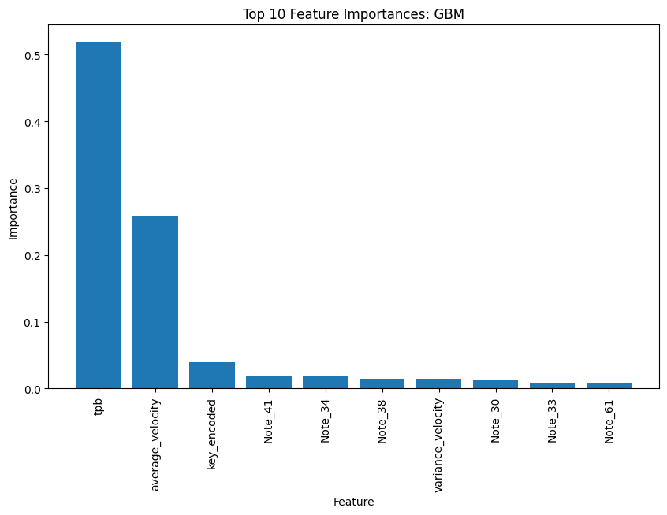

```python
gbm_importances = top_feat(gb_classifier, "GBM", X_train, n=10)
```

## Inference: Unlabeled

### Method:

- Choose the GBM classifier based on performance and scalability
- For each class, take the maximum predicted probability for the record that corresponds to the predicted composer. Hypothesis: those files with the lowest max. predicted probability are likely to not belong to any of the classes in the training set. Examine the distribution of the maximum probability and choose a threshold, below which we predict that a file does not belong to any of our labeled classes.

Knowing that there are "not many" we can guess at what might be a decent threshold. Further testing would require more labeling of files that are know to not belong to any of our 4 labeled composers.

```python
# Predict the target on the unlabeled set
y_pred_unlabeled = gb_classifier.predict(z)
# Get the classification probabilities for each class
y_proba_unlabeled = gb_classifier.predict_proba(z)
```

```python
print(label_encoder_composer.inverse_transform(y_pred_unlabeled))
```

```
['Brahms' 'Schubert' 'Schubert' 'Beethoven' 'Bach' 'Brahms' 'Beethoven'
 'Beethoven' 'Beethoven' 'Beethoven' 'Beethoven' 'Beethoven' 'Schubert'
 'Bach' 'Beethoven' 'Bach' 'Beethoven' 'Brahms' 'Bach' 'Schubert' 'Bach'
 'Beethoven' 'Bach' 'Beethoven' 'Schubert' 'Beethoven' 'Beethoven'
 'Beethoven' 'Beethoven' 'Schubert' 'Beethoven' 'Beethoven' 'Schubert'
 'Beethoven' 'Beethoven']
```

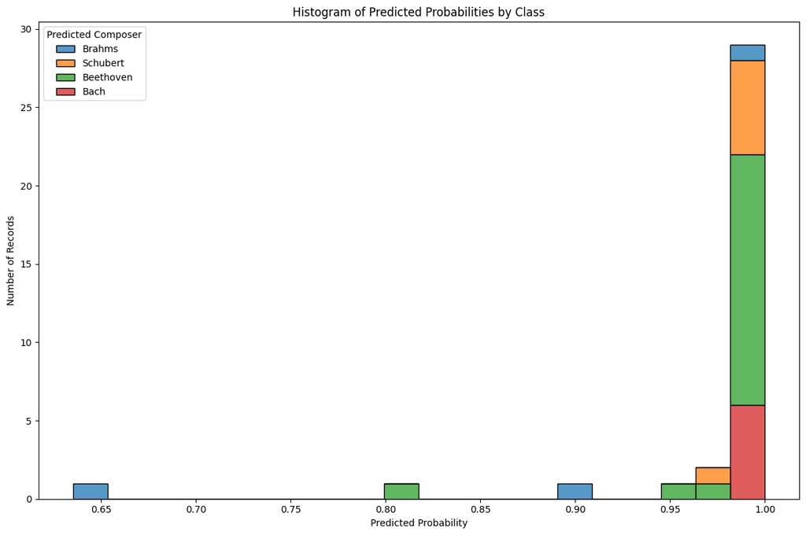

```python
# Plot histogram of the maximum probabilities for each file, and color by predicted composer

# Prepare the data for plotting
df_plot = pd.DataFrame(y_proba_unlabeled, columns=[f'Class_{i}_prob' for i in range(y_proba_unlabeled.shape[1])])
df_plot['Predicted_Class'] = y_pred_unlabeled
df_plot['Predicted Composer'] = label_encoder_composer.inverse_transform(y_pred_unlabeled)

# Extract the highest predicted probability for each record
df_plot['Max_Probability'] = df_plot[[f'Class_{i}_prob' for i in range(y_proba_unlabeled.shape[1])]].max(axis=1)

# Plot the histogram
plt.figure(figsize=(12, 8))
sns.histplot(data=df_plot, x='Max_Probability', hue='Predicted Composer', multiple='stack', palette='tab10', bins=20)
plt.title('Histogram of Predicted Probabilities by Class')
plt.xlabel('Predicted Probability')
plt.ylabel('Number of Records')
plt.tight_layout()
plt.show()
```

Based on this histogram, we can select a probability threshold such that

```
if max(predicted probability for all classes) < threshold
then midi file is NOT one of the 4 composers in training data
```

To begin, I'd select a threshold of 0.91, resulting in 3 out of the 35 midi files being classified as NOT belonging to our 4 known composers.

```python
final_threshold_p = 0.91
```

```python
final_output= df_unlabeled[['filename']].merge(df_plot[df_plot.Max_Probability<final_threshold_p],left_index=True, right_index=True, how = 'right').drop(
    labels=['Predicted_Class','Predicted Composer'], axis=1)
```

```python
# Create final output of files we believe to not belong to any of our 4 composers
print(final_output['filename'])
final_output['filename'].to_csv('Identified_files.csv')
```

```
0     0.8014751784512073_adj.mid
5     0.3559970176888735_adj.mid
28    0.1960551158929671_adj.mid
Name: filename, dtype: object
```

The following files are predicted to NOT belong to the 4 composers in our labeled dataset based on the methods employed above.

0.8014751784512073_adj.mid

0.3559970176888735_adj.mid

0.1960551158929671_adj.mid